# Fysieke gezondheid en wiskundige geletterdheid

cigaretten en POD1

Wesley Maebe

Creer sigaretten classificatie tabel

```r
Rokerclass <- data.frame(
  Min = c(0, 1),
  Max = c(0, 1000),
  Classificatie = c("geen roker", "roker")
)
```

Uitlezen data

```r
data <- read_csv('../data/npe-1920-wiskundige-geletterdheid.csv')
usedData <- na.omit(data.frame(CigaretteConsumption=data$CigaretteConsumption,
                       GradesPOD1=data$GradePOD1))
workData <- transform(usedData, CigaretteConsumptionClassificatie=Rokerclass$Classificatie[findInterval(CigaretteConsumption,Rokerclass$Min)])
glimpse(workData)
```

```
## Rows: 200
## Columns: 3
## $ CigaretteConsumption              <dbl> 0, 0, 40, 0, 20, 0, 0, 0, 0, 0, 0...
## $ GradesPOD1                        <dbl> 0, 12, 14, 12, 11, 14, 10, 10, 13...
## $ CigaretteConsumptionClassificatie <chr> "geen roker", "geen roker", "roke...
```

### Visualisatie van de dataset

De onafhankelijke variabele (`CigaretteConsumption`) wordt afgebeeld op de X-as, de afhankelijke (`GradesPOD1`) op de Y-as. We tekenen ook de regressierechte:

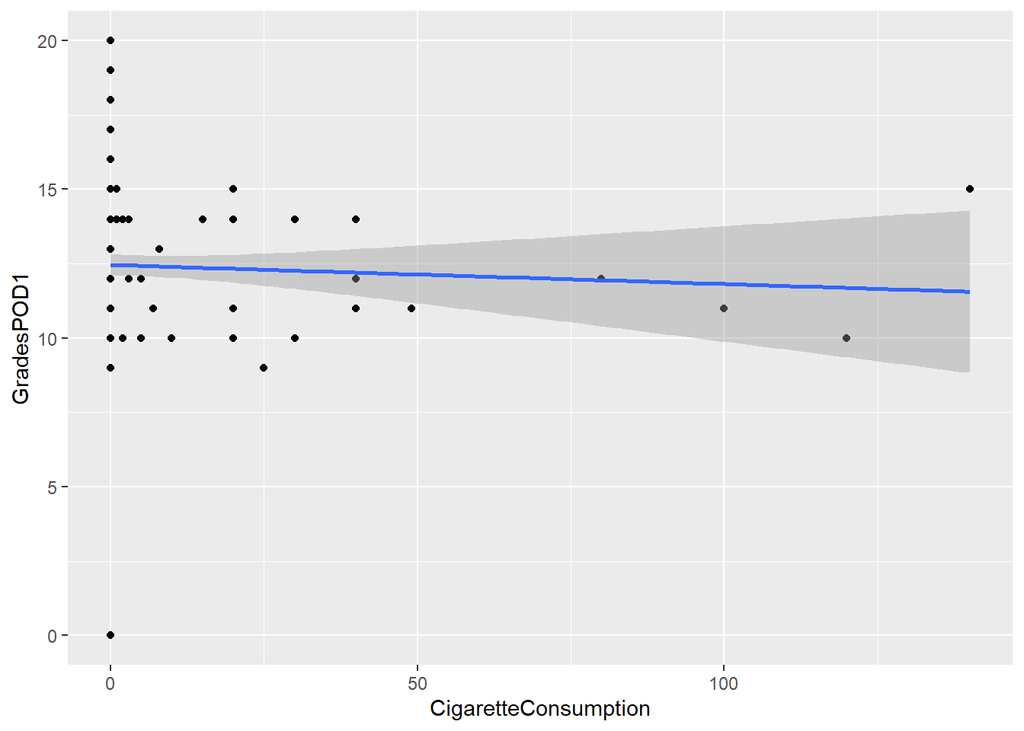

```r
ggplot(data = usedData, mapping = aes(x = CigaretteConsumption, y = GradesPOD1)) +
  geom_point() +
  geom_smooth(method = "lm", formula = y ~ x)
```

Op basis van de grafische voorstelling is het duidelijk dat de verdeling helemaal geen rechte is. Immers uitschieters in het rookgedrag hebben een grote invloed op de helling van de rechte. Veel van de deelnemers zijn niet rokers. We maken dus beter een verdeling rokers versus niet-rokers

### gemiddelden bekijken

```r
mx <- mean(usedData$CigaretteConsumption)
my <- mean(usedData$GradesPOD1)
mx
```

```
## [1] 4.615
```

```r
my
```

```
## [1] 12.435
```

We bepalen het gemiddelde van Y als alternatief voor de rechte. Y komt neer op ongeveer 12.5

### regressie

```r
#                                       afh                           onafh
regr_Cigarette_GradeMath4IT <- lm(workData$GradesPOD1 ~workData$CigaretteConsumption)
regr_Cigarette_GradeMath4IT
```

```
##
## Call:
## lm(formula = workData$GradesPOD1 ~ workData$CigaretteConsumption)
##
## Coefficients:
##                   (Intercept)  workData$CigaretteConsumption
##                     12.464652                      -0.006425
```

Intersect rond het gemiddelde dus dat is oké. Kleine negatieve helling.

### correlatie

```r
correlatieCoefficient <- cor(x = workData$CigaretteConsumption, y = workData$GradesPOD1)
determinatieCoefficient <- correlatieCoefficient^2
correlatieCoefficient
```

```
## [1] -0.04493336
```

```r
determinatieCoefficient
```

```
## [1] 0.002019007
```

Zoals verwacht is het verband met de huidige waarden verwaarloosbaar. R onder 0.3 en R² onder 0.1

Wat als we gewoon een onderscheid maken tussen Geen roker en roker. De onafhankelijke wordt dan een kwalitatieve waarde De afhankelijke blijft de waarden van de behaalde cijfers dus kwantitatief

### visualisatie kwalitatief

```r
strategy_A <- workData$GradesPOD1[workData$CigaretteConsumptionClassificatie == 'geen roker']
strategy_B <- workData$GradesPOD1[workData$CigaretteConsumptionClassificatie == 'roker']
```

```r
sum (workData$CigaretteConsumptionClassificatie == 'geen roker')
```

```
## [1] 168
```

```r
sum (workData$CigaretteConsumptionClassificatie == 'roker')
```

```
## [1] 32
```

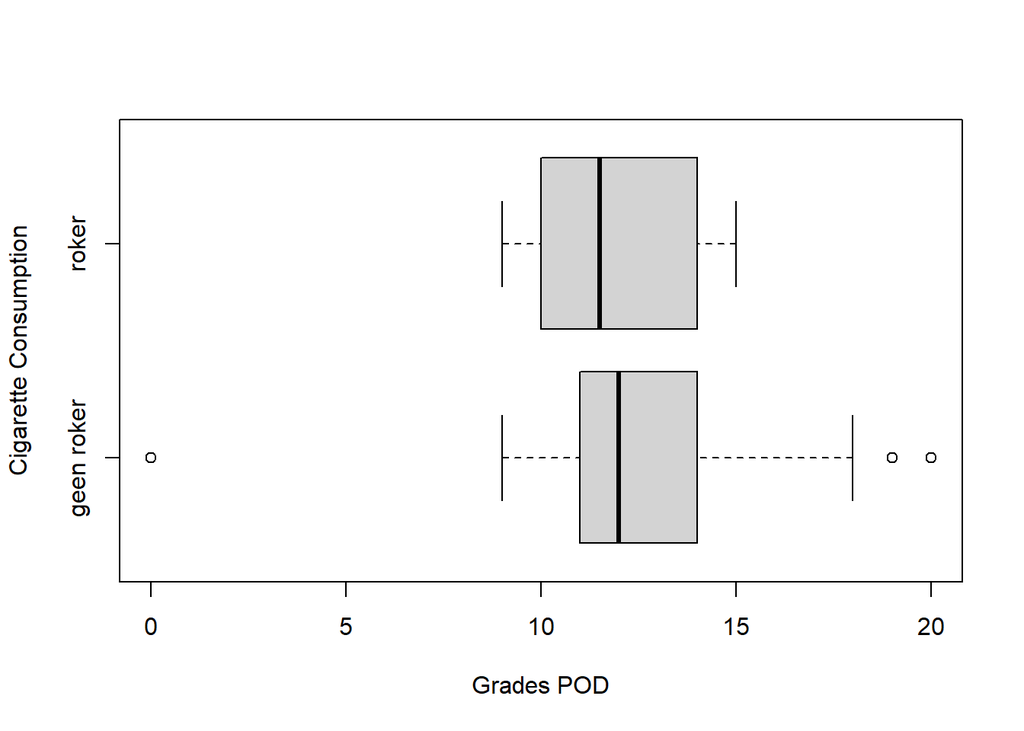

```r
# Boxplot
boxplot(workData$GradesPOD1 ~ workData$CigaretteConsumptionClassificatie, horizontal = TRUE, xlab = "Grades POD", ylab = "Cigarette Consumption")
```

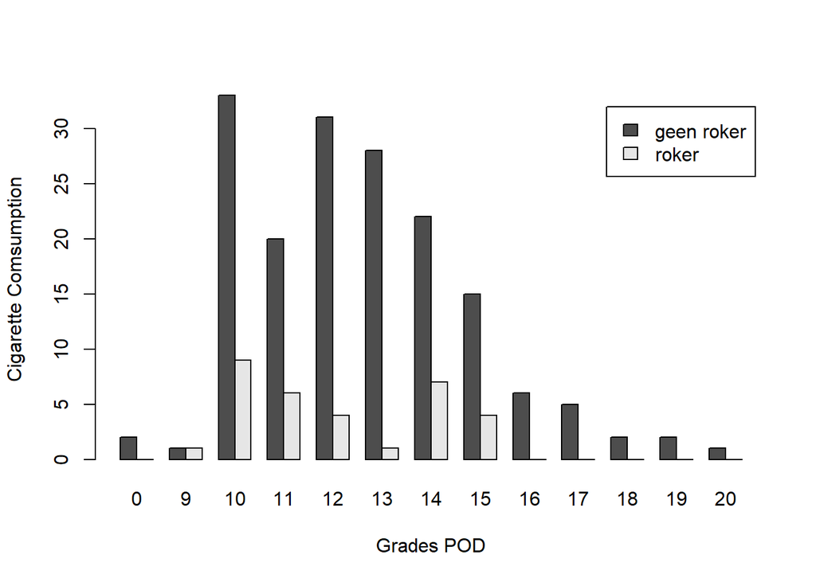

```r
# Clustered bar chart (histogram)
frequencies <- table(workData$GradesPOD1, workData$CigaretteConsumptionClassificatie)
barplot(t(frequencies), beside = TRUE, legend = TRUE, xlab = "Grades POD", ylab = "Cigarette Comsumption")
```

Visueel lijkt het alsof de rokers licht slechter scoren dan de niet rokers.

```r
t.test(strategy_A, strategy_B, alternative = 'greater', conf.level = 1 - 0.05)
```

```
##
##  Welch Two Sample t-test
##
## data:  strategy_A and strategy_B
## t = 1.3091, df = 54.369, p-value = 0.09801
## alternative hypothesis: true difference in means is greater than 0
## 95 percent confidence interval:
##  -0.1441224        Inf
## sample estimates:
## mean of x mean of y
##  12.51786  12.00000
```

De Nulhypothese kan niet verworpen worden. Er is dus geen wezenlijk verband tussen roken en niet roken.

```r
# Pooled standard deviation for two samples x and y
pooled_sd <- function(x, y) {
  sd_x <- sd(x, na.rm = TRUE)
  sd_y <- sd(y, na.rm = TRUE)
  n_x <- length(x)
  n_y <- length(y)

  sqrt( ((n_x - 1) * sd_x^2 + (n_y - 1) * sd_y^2)
        / (n_x + n_y - 2))
}

# Effect size, Cohen's d
cohens_d <- function(x, y) {
  (mean(y, na.rm = TRUE) - mean(x, na.rm = TRUE)) / pooled_sd(x, y)
}
```

```r
cohens_d(strategy_A, strategy_B)
```

```
## [1] -0.2081166
```

Quod demostrandum.Een klein verschil/effect gevonden wel onder de 0.4